# Beltrame_Ginevra_Rlab04

2024-06-16

## Exercise 1: Bayesian Inference for Poisson model

- a well established and diffused method for detecting a disease in blood fails to detect the presence of disease in 15% of the patients that actually have the disease.
- A young UniPD startUp has developed an innovative method of screening. During the qualification phase, a random sample of $n = 75$ patients known to have the disease is screened using the new method.
1. What is the probability distribution of $y$, the number of times the new method fails to detect the disease?
2. On the $n = 75$ patients sample, the new method fails to detect the disease in $y = 6$ cases. What is the frequentist estimator of the failure probability of the new method?
3. Setup a bayesian computation of the posterior probability, assuming a beta distribution with mean value 0.15 and standard deviation 0.14. Plot the posterior distribution for $y$, and mark on the plot the mean value and variance
4. Perform a test of hypothesis assuming that if the probability of failing to the detect the disease in ill patients is greater or equal than 15%, the new test is no better that the traditional method. Test the sample at a 5% level of significance in the Bayesian way.
5. Perform the same hypothesis test in the classical frequentist way.

### Solution

By formulating the problem in terms of a Hypothesis Testing paradigm, we can define as the null hypothesis $H_0$ the statement “The patient has the disease”. It follows that the situation in which the patient indeed has the disease ($H_0$ is true) but the test rejects the null hypothesis is a type I error. It is moreover said that the well-established test has a false negative rate of $\alpha = 0.15$, resulting in a sensitivity of 85%.

Assuming each test to be an independent Bernoulli trial with a probability of $\alpha'$ for a false negative result, then the number of false negatives $y$ in $n=75$ tests follows a Binomial distribution:

$$P(y) = \binom{n}{y} \alpha'^y (1 - \alpha')^{n - y}$$

#### (b) Frequentist estimator of the failure probability

In a frequentist approach, an unbiased estimator for the Binomial distribution is $p_F = \frac{y}{n} = \frac{6}{75} = 0.08$.

#### (c) Bayesian computation of the posterior probability

Assuming a beta distribution with

$$E[x] = \frac{\alpha}{\alpha + \beta} = 0.15; \qquad Var(x) =
\frac{αβ}{(α + β)^2(α + β + 1)} = 0.14^2 = 0.0196 \\
\text{which results in} \\
\alpha = \frac{E[x]^2(1-E[x])}{Var(x)} - E[x] = 0.8258; \qquad \beta =
\frac{1-E[x]}{E[x]}; \quad \alpha = \frac{E[x](1-E[x])^2}{Var(x)} -
(1-E[x]) = 4.6793$$

It follows that the desired Beta prior is $Beta(\alpha, \beta) = Beta(0.8258, 4.6793)$. The posterior pdf is then obtained by multiplying it by the likelihood, as in the following, where $n=75$ and $y=6$.

$$P(\pi | y,n,H) = \frac{1}{B(y + α, n − y + β)
} \pi^{y+\alpha-1} (1-\pi)^{n-y+\beta-1} = Beta(y + α, n − y + β) =
Beta(6.8258, 73.6793)$$

The mean and variance are therefore calculated as in the following.

$$E[x] = \frac{\alpha}{\alpha + \beta} = 0.0848 \qquad Var(x) =
\frac{αβ}{(α + β)^2(α + β + 1)} = 0.0010$$

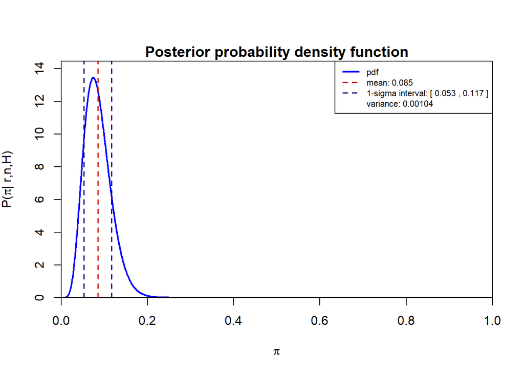

```r
n <- 75
y <- 6
mu <- 0.15
sigma <- 0.14
alpha <- mu^2 * (1-mu) / sigma^2 - mu
beta <- alpha * (1-mu)/mu

n.sample <- 2000
delta.p <- 1/n.sample

p <- seq(from=1/(2*n.sample), by=1/n.sample , length.out=n.sample)

Pi_posterior <- function(x) {
  return(dbeta(x, y+alpha, n-y+beta))
}

pi_values <- sapply(p, Pi_posterior)

plot(p, pi_values , type="l", lwd=2, col='blue', xlim=c(0,1), ylim=c(0,max(pi_values)+1), xaxs="i", yaxs="i", xlab=expression(pi), ylab=expression(paste('P(', pi, '| r,n,H)')))

title(main="Posterior probability density function", line=0.3, cex.main=1.2)
p.mean <- (y+alpha) /(n+alpha+beta)
abline(v=p.mean , lty=2, col='red3', lwd=1.5)

p.variance <- (alpha+y)*(n+alpha+beta)/((n+alpha+beta)^2*(n+alpha+beta+1))

abline(v=p.mean - sqrt(p.variance) , lty=2, col='navy', lwd=1.5)
abline(v=p.mean + sqrt(p.variance) , lty=2, col='navy', lwd=1.5)

legend('topright', legend=c('pdf', paste('mean:', round(p.mean, 3)), paste('1-sigma interval: [', round(p.mean - sqrt(p.variance), 3), ',', round(p.mean + sqrt(p.variance), 3), ']'), paste('variance:', round(p.variance, 5))), col=c('blue', 'red3', 'navy', ' white'), lty=c(1, 2, 2, 1), lwd=c(2, 1.5, 1.5, 1), cex=0.7)
```

#### (d) Bayesian Hypothesis testing

Perform a test of hypothesis assuming that if the probability of failing to the detect the disease in ill patients is greater or equal than 15%, the new test is no better than the traditional method. Test the sample at a 5% level of significance in the Bayesian way.

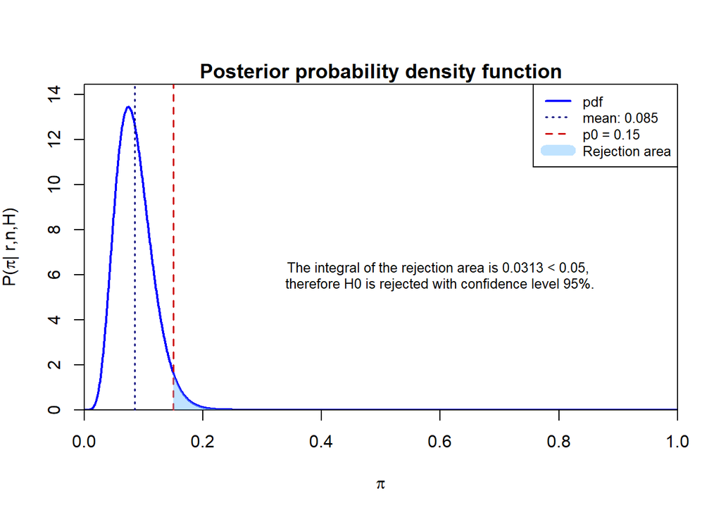

```r
n <- 75
y <- 6
mu <- 0.15
sigma <- 0.14
alpha <- mu^2 * (1-mu) / sigma^2 - mu
beta <- alpha * (1-mu)/mu

n.sample <- 2000
delta.p <- 1/n.sample

p <- seq(from=1/(2*n.sample), by=1/n.sample , length.out=n.sample)

Pi_posterior <- function(x) {
  return(dbeta(x, y+alpha, n-y+beta))
}

pi_values <- sapply(p, Pi_posterior)

plot(p, pi_values , type="l", lwd=2, col='blue', xlim=c(0,1), ylim=c(0,max(pi_values)+1), xaxs="i", yaxs="i", xlab=expression(pi), ylab=expression(paste('P(', pi, '| r,n,H)')))

title(main="Posterior probability density function", line=0.3, cex.main=1.2)
p.mean <- (y+alpha) /(n+alpha+beta)
abline(v=p.mean , lty=3, col='navy', lwd=1.5)

sig_lev <- 0.05

p0 <- 0.15
abline(v=p0, col='red3', lty=2, lwd=1.5)

p_red <- p[p>=p0]
y_red <- pi_values[p>=p0]
polygon(c(p0, p_red), c(0, y_red), col=rgb(130/255, 200/255, 255/255, 0.5), border=FALSE)

integral_from_p0 <- function(sig_lev) {
  return(integrate(Pi_posterior, lower = p0, upper = 1)$value)
}

labels <- c('pdf', paste('mean:', round(p.mean, 3)), paste('p0 =', p0), 'Rejection area')
colors <- c('blue', 'navy', 'red3', rgb(130/255, 200/255, 255/255, 0.5))
ltys <- c(1, 3, 2, 1)
lwds <- c(2, 1.5, 1.5, 10)

legend('topright', legend=labels, col=colors, lty=ltys, lwd=lwds, cex=0.8)
text(x=0.6, y=6, labels=paste('The integral of the rejection area is', signif(integral_from_p0(sig_lev), 3), '< 0.05, \ntherefore H0 is rejected with confidence level 95%.'), cex=0.8)
```

#### (e) Frequentist Hypothesis testing

```r
y <- 6; n <- 75; p0 <- 0.15
freq_test <- binom.test(y, n, p0, alternative = 'less')
freq_test
```

```
##
##  Exact binomial test
##
## data:  y and n
## number of successes = 6, number of trials = 75, p-value = 0.05435
## alternative hypothesis: true probability of success is less than 0.15
## 95 percent confidence interval:
##  0.0000000 0.1517971
## sample estimates:
## probability of success
##                   0.08
```

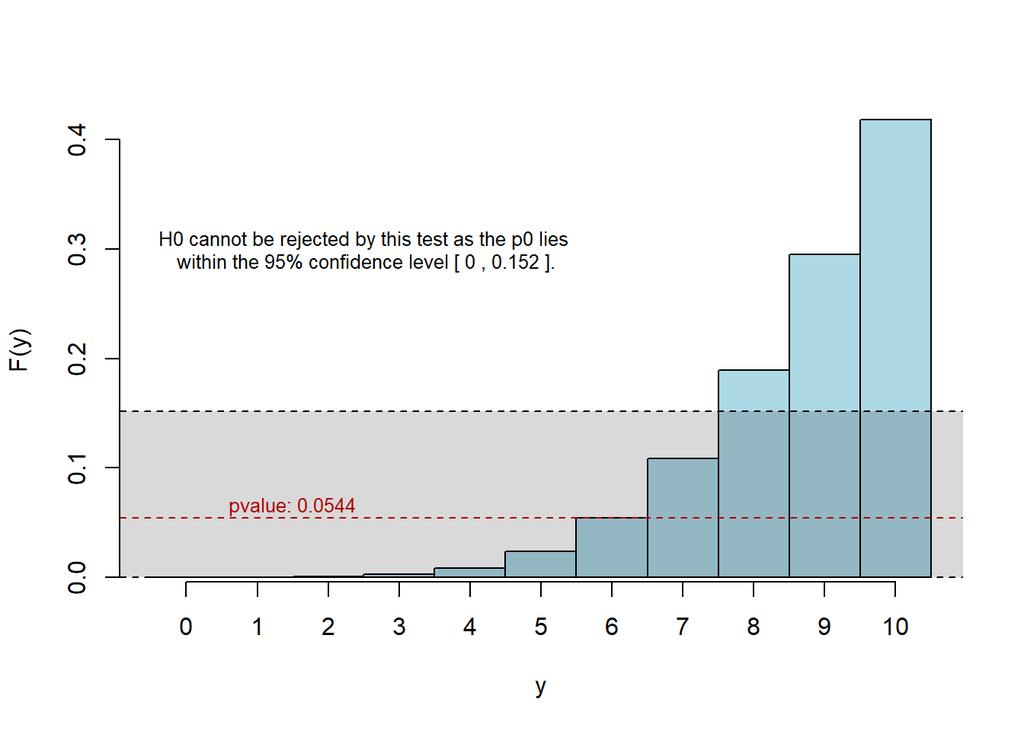

```r
ys <- 0:10
barplot(pbinom(ys, n, p0), col='lightblue', xlab='y', ylab='F(y)', width = 1, space = 0)
abline(h=freq_test$p.value, col='red3', lty=2)
text(2, freq_test$p.value*1.2, paste('pvalue:', signif(freq_test$p.value, 3)), cex=0.8, col='red3')
axis(1, at = 0:10 + 0.5, labels=0:10)
polygon(c(-0.5, 11.5, 11.5, -0.5), c(freq_test$conf.int[1], freq_test$conf.int[1], freq_test$conf.int[2], freq_test$conf.int[2]), col=rgb(0, 0, 0, 0.15), border=FALSE)
abline(h=c(freq_test$conf.int[1], freq_test$conf.int[2]), col='black', lty=2)

text(3, 0.3, paste('H0 cannot be rejected by this test as the p0 lies\n within the 95% confidence level [', signif(freq_test$conf.int[1], 3), ',', signif(freq_test$conf.int[2], 3), '].'), cex=0.8)
```

## Exercise 2

- a researcher has collected $n = 16$ observations that are supposed to come from a Normal distribution with known variance $σ^2 = 4$:

  | 4.09 | 4.68 | 1.87 | 2.62 | 5.58 | 8.68 | 4.07 | 4.78 |
  | --- | --- | --- | --- | --- | --- | --- | --- |
  | 4.79 | 4.49 | 5.85 | 5.09 | 2.40 | 6.27 | 6.30 | 4.47 |

- assuming the prior is a step function:

$$g(\mu) = \begin{cases}
\mu & \text{for } 0 < \mu \leq 3 \\
3 & \text{for } 3 < \mu ≤ 5 \\
8 − \mu & \text{for } 5 < \mu ≤ 8 \\
0 & \text{for } \mu > 8
\end{cases}$$

1. find the posterior distribution, the posterior mean and standard deviation
2. find the 95% credibility interval for µ
3. plot the posterior distribution, indicating on the same plot: the mean value, the standard deviation, and the 95% credibility interval
4. plot, on the same graph, the prior, the likelihood and the posterior distribution

### Solution

From Bayes’ theorem, and assuming the Likelihood $P(D|\mu, \sigma)$ follows a Guassian distribution and that all the collected data points are independent,

$$P(\mu | D, \sigma) \propto P(D | \mu, \sigma) \cdot P(\mu | \sigma) =
\prod_j \frac{1}{\sqrt{2\pi\sigma^2}} \ e^{-\frac{(y_j -
\mu)^2}{2\sigma^2}} \ P(\mu | \sigma)$$

Moreover, the prior distribution $P(\mu) = P(\mu | \sigma)$ is the given step function, so the posterior can be calculated (apart from a normalizing factor) as in the following.

$$P(\mu | D, \sigma) \propto \begin{cases}
\prod_j \frac{\mu}{\sqrt{2\pi\sigma^2}} \ e^{-\frac{(y_j -
\mu)^2}{2\sigma^2}} & \text{for } 0 < \mu \leq 3 \\
\prod_j \frac{3}{\sqrt{2\pi\sigma^2}} \ e^{-\frac{(y_j -
\mu)^2}{2\sigma^2}} & \text{for } 3 < \mu ≤ 5 \\
\prod_j \frac{8-\mu}{\sqrt{2\pi\sigma^2}} \ e^{-\frac{(y_j -
\mu)^2}{2\sigma^2}} & \text{for } 5 < \mu ≤ 8 \\
0 & \text{for } \mu > 8
\end{cases}$$

Specifically, the variance is known $\sigma^2 = 4$ and so are the data points $\{y_j\}_{j=1...n} = \{4.09, 4.68, 1.87, 2.62, 5.58, 8.68, 4.07, 4.78, 4.79, 4.49, 5.85, 5.09, 2.40, 6.27, 6.30, 4.47\}$ with $n=16$. The posterior distribution can therefore be computed analytically, and subsequantly plotted as a function of the sole $\mu$.

I can now plot the function and infer the mean, standard deviation and 95% credibility interval.

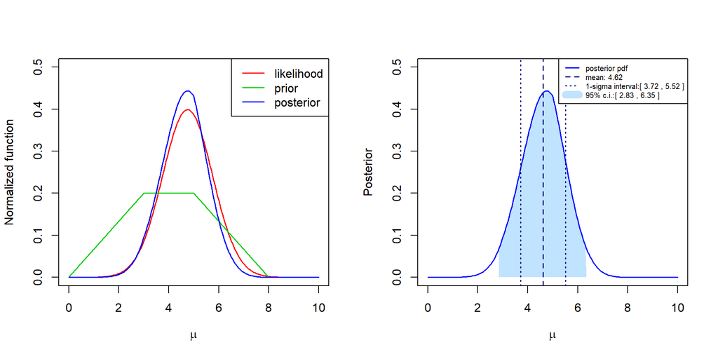

```r
y <- c(4.09, 4.68, 1.87, 2.62, 5.58, 8.68, 4.07, 4.78, 4.79, 4.49, 5.85, 5.09, 2.40, 6.27, 6.30, 4.47)
n <- length(y)
sigma <- 4

likelihood_function_unnorm <- function(mu){
  return(prod(dnorm(y, mu, sigma)))
}
likelihood_vec_unnorm <- Vectorize(likelihood_function_unnorm, c('mu'))
L_norm <- integrate(likelihood_vec_unnorm, 0, 10)$value

likelihood_function_norm <- function(mu){
  return(prod(dnorm(y, mu, sigma))/L_norm)
}
likelihood_function <- Vectorize(likelihood_function_norm, c('mu'))

prior_function <- function(mu) {
  if (mu > 0 & mu <= 3)     { return(mu) }
  else if (mu > 3 & mu <= 5){ return(3) }
  if (mu > 5 & mu <= 8)     { return(8 - mu) }
  else                      { return(0) }
}

prior_vec <- Vectorize(prior_function, c('mu'))

posterior_function_unnorm <- function(mu) {
  return(likelihood_function(mu)*prior_vec(mu))
}

posterior_norm <- integrate(posterior_function_unnorm, 0, 10)$value

posterior_function <- function(mu) {
  return(posterior_function_unnorm(mu)/posterior_norm)
}

mu_step <- 0.05
mu_values <- seq(0, 10, mu_step)
likelihood_values <- sapply(mu_values, likelihood_function)
prior_values <- sapply(mu_values, prior_function)
posterior_values <- sapply(mu_values, posterior_function)

par(mfrow=c(1,2))

plot(mu_values, mu_values, col='white', xlab=expression(mu), ylim=c(0,0.5), ylab='Normalized function')
lines(mu_values, likelihood_values, col='red', lty=1, lwd=1.5)
lines(mu_values, prior_values/15, col='green3', lty=1, lwd=1.5)
lines(mu_values, posterior_values, col='blue', lty=1, lwd=1.5)
legend('topright', col=c('red', 'green3', 'blue'), legend=c('likelihood', 'prior', 'posterior'), lty=1, lwd=1.5)

post_mean <- sum(mu_values*posterior_values*mu_step)
post_var <- sum(mu_values^2 *posterior_values*mu_step) - post_mean^2

cf <- 0.95
cf_upper <- cf + (1-cf)/2
cf_lower <- (1-cf)/2

# Define the integral function from 0 to a
integral_to_a <- function(a) {
  integrate(posterior_function, lower = 0, upper = a)$value
}

# Define the function to solve the equation
find_a <- function(target) {
  to_solve <- function(a) {
    integral_to_a(a) - target
  }
  result <- uniroot(to_solve, lower = 0, upper = 10)
  return(result$root)
}

# Find a such that the integral equals 0.025
a_value <- find_a(cf_lower)
b_value <- find_a(cf_upper)

mu_red <- mu_values[mu_values >= a_value & mu_values <= b_value]
posterior_red <- posterior_values[mu_values >= a_value & mu_values <= b_value]

plot(mu_values, mu_values, col='white', xlab=expression(mu), ylim=c(0,0.5), ylab='Posterior')
polygon(c(a_value, mu_red, b_value), c(0, posterior_red, 0), col=rgb(130/255, 200/255, 255/255, 0.5), border=FALSE)
lines(mu_values, posterior_values, col='blue', lty=1, lwd=1.5)
abline(v=post_mean, col='navy', lwd=1.5, lty=2)
abline(v=post_mean-sqrt(post_var), col='navy', lwd=1.5, lty=3)
abline(v=post_mean+sqrt(post_var), col='navy', lwd=1.5, lty=3)

leg.colors <- c('blue', 'navy', 'navy', rgb(130/255, 200/255, 255/255, 0.5))
leg.labels <- c('posterior pdf', paste('mean:', signif(post_mean,3)), paste('1-sigma interval:[', signif(post_mean-sqrt(post_var), 3), ',', signif(post_mean+sqrt(post_var), 3), ']'), paste('95% c.i.:[', signif(a_value, 3), ',', signif(b_value, 3), ']'))
leg.lwd <- c(1.5, 1.5, 1.5, 10)
leg.lty <- c(1, 2, 3, 1)
legend('topright', legend=leg.labels, col=leg.colors, lwd=leg.lwd, lty=leg.lty, cex=0.625)
```

## Exercise 3 - Six Boxes Toy Model : inference

Labeling the boxes H0 H1 H2 H3 H4 H5, write a program in R that:

1. selects a random box
2. makes random sampling from the box
3. prints on the standard output the probability of selecting each box
4. plots the probability for each box as a function of the number of trial

### Solution

```r
# White is 1, Black is 0
boxes <- list(rep(0, 5), c(rep(0, 4), 1), c(rep(0, 3), rep(1, 2)), c(rep(0, 2), rep(1, 3)), c(0, rep(1, 4)), rep(1, 5))

set.seed(89540)
n_extractions <- 20
N_boxes <- 6
prob_boxes <- matrix(NA, nrow = N_boxes, ncol = n_extractions)

random_box_index <- 1
whites_counter <- 0

for (n in 1:n_extractions){
  random_sampling_from_box <- sample(boxes[[random_box_index]], size=20, replace=TRUE)
  whites_counter <- whites_counter + sample(boxes[[random_box_index]], size=1, replace=TRUE)
  norms <- numeric(n_extractions)

  for (j in 1:N_boxes){
    if (n==1){
      prob_boxes[j, n] <- (5-(j-1))/5 * 1/5 *5/3
    }
    else {
      norms[n] <- sum(prob_boxes[, n-1])
      prob_boxes[j, n] <- prob_boxes[j, n-1] * (5-(j-1))/5 * 1/norms[n]
    }
  }
}

cat('The probabilities of having selected each box are, respectively,', signif(prob_boxes[,n_extractions],3))
```

```
## The probabilities of having selected each box are, respectively, 0.986 0.0114 3.6e-05 1.08e-08 1.03e-14 0
```

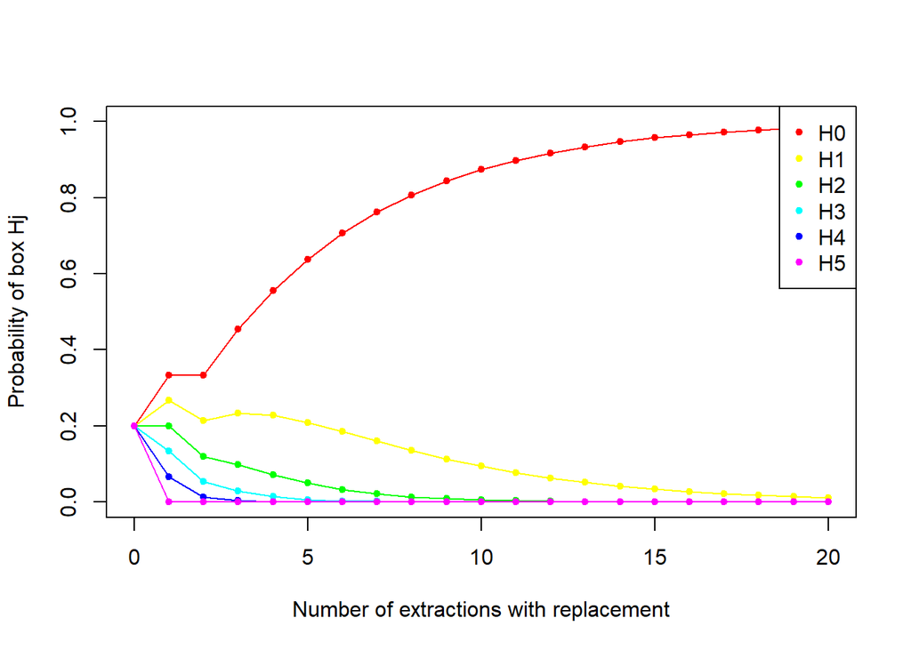

```r
colors <- rainbow(N_boxes)
plot(1:n_extractions, 1:n_extractions, type='p', pch=19, col='white', xlim=c(0,n_extractions), ylim=c(0,1), xlab='Number of extractions with replacement', ylab='Probability of box Hj')

for (j in 1:N_boxes){
  lines(0:n_extractions, c(0.2, prob_boxes[j, ]), col=colors[j], lwd=1)
  points(0:n_extractions, c(0.2, prob_boxes[j, ]), pch=20, col=colors[j])
}

legend('topright', col=colors, legend=c('H0', 'H1', 'H2', 'H3', 'H4', 'H5'), pch=20)
```